# R Assignment – Group 7: Hospital (Admissions, Length of Stay and Cost)

MIDA-B – R&Python programming for business and management

Group 7: Adriana Bonanca García, Fernando Herráiz Nieto Márquez, Juan María Rodríguez Estrada

8 November 2026

# 1. Setup

```r
# Load every library used in the document
library(dplyr)      # data manipulation (filter, select, mutate, group_by, summarise)
library(tidyr)      # pivot_wider to reshape small tables
library(ggplot2)    # charts
library(lubridate)  # dates and days of the week

# Colours used in all charts: one colour for the message, grey for the rest
col_main  <- "#0E7C86"
col_grey  <- "#B8BEC6"
col_loss  <- "#C0392B"

# Folder where the charts for the presentation are saved
dir.create("charts", showWarnings = FALSE)

# Helper function to write euro amounts in the text (e.g. 190,488 euros)
# "€" is the euro symbol; negative amounts are written as -€622,966
eur <- function(x) {
  amount <- format(abs(round(x)), big.mark = ",", trim = TRUE)
  ifelse(x < 0, paste0("-€", amount), paste0("€", amount))
}
```

# 2. Data loading and first look

```r
# Read the CSV file by its name only (it is in the same folder as this .Rmd)
data_raw <- read.csv("Group_7.csv")

# Size of the data: rows and columns
dim(data_raw)
```

```
## [1] 2739   22
```

```r
# Type of every column
str(data_raw)
```

```
## 'data.frame':    2739 obs. of  22 variables:
##  $ admission_id          : chr  "A700001" "A700002" "A700003" "A700004" ...
##  $ patient_id            : chr  "P51358" "P52050" "P51661" "P51110" ...
##  $ admission_datetime    : chr  "2025-07-01 02:02" "2025-07-01 14:26" "2025-07-01 19:05" "2025-07-02 08:04" ...
##  $ discharge_datetime    : chr  "2025-07-07 13:32" "2025-07-02 14:29" "2025-07-07 14:23" "2025-07-07 10:52" ...
##  $ length_of_stay_days   : num  6.48 1 5.8 5.12 9.33 ...
##  $ admission_type        : chr  "Emergency" "Emergency" "Emergency" "Elective" ...
##  $ department            : chr  "Orthopaedics" "Paediatrics" "Internal Medicine" "Orthopaedics" ...
##  $ diagnosis_group       : chr  "Hip fracture" "Gastroenteritis" "Urinary tract infection" "Hip replacement" ...
##  $ age                   : int  81 6 97 61 79 81 66 76 27 84 ...
##  $ payer                 : chr  "Public agreement" "Civil servants mutual" "Public agreement" "Public agreement" ...
##  $ comorbidity_index     : int  0 0 4 0 0 0 3 0 0 2 ...
##  $ severity_level        : int  2 1 2 2 1 1 2 2 1 2 ...
##  $ surgery_flag          : int  1 0 0 1 0 1 1 1 0 0 ...
##  $ icu_days              : int  0 0 0 0 0 0 0 0 0 0 ...
##  $ complications_flag    : int  0 0 0 0 1 0 0 0 0 0 ...
##  $ consultant_id         : chr  "C25" "C36" "C02" "C22" ...
##  $ waiting_list_days     : int  NA NA NA 67 NA 68 39 36 NA NA ...
##  $ ed_boarding_hours     : num  0.6 1.6 6 NA 1.3 NA NA NA 0.8 0.6 ...
##  $ hospital_occupancy_pct: num  82.7 82.7 82.7 81.3 81.3 81.3 81.3 81.3 81.3 81.3 ...
##  $ discharge_destination : chr  "Home with support" "Home" "Home with support" "Home" ...
##  $ cost_eur              : num  11932 750 4514 10645 9491 ...
##  $ reimbursement_eur     : num  15643 722 6207 12491 4580 ...
```

```r
# Summary statistics of every column
summary(data_raw)
```

```
##  admission_id        patient_id        admission_datetime discharge_datetime
##  Length:2739        Length:2739        Length:2739        Length:2739
##  Class :character   Class :character   Class :character   Class :character
##  Mode  :character   Mode  :character   Mode  :character   Mode  :character
##
##
##
##
##  length_of_stay_days admission_type      department        diagnosis_group
##  Min.   :-4.000      Length:2739        Length:2739        Length:2739
##  1st Qu.: 2.745      Class :character   Class :character   Class :character
##  Median : 5.130      Mode  :character   Mode  :character   Mode  :character
##  Mean   : 6.804
##  3rd Qu.: 8.950
##  Max.   :52.700
##
##       age            payer           comorbidity_index severity_level
##  Min.   :  0.00   Length:2739        Min.   :0.000     Min.   :1.000
##  1st Qu.: 45.50   Class :character   1st Qu.:0.000     1st Qu.:1.000
##  Median : 67.00   Mode  :character   Median :0.000     Median :2.000
##  Mean   : 60.55                      Mean   :0.803     Mean   :1.679
##  3rd Qu.: 79.00                      3rd Qu.:1.000     3rd Qu.:2.000
##  Max.   :121.00                      Max.   :7.000     Max.   :4.000
##                                      NA's   :109
##   surgery_flag       icu_days      complications_flag consultant_id
##  Min.   :0.0000   Min.   :0.0000   Min.   :0.00000    Length:2739
##  1st Qu.:0.0000   1st Qu.:0.0000   1st Qu.:0.00000    Class :character
##  Median :0.0000   Median :0.0000   Median :0.00000    Mode  :character
##  Mean   :0.2899   Mean   :0.1574   Mean   :0.05842
##  3rd Qu.:1.0000   3rd Qu.:0.0000   3rd Qu.:0.00000
##  Max.   :1.0000   Max.   :7.0000   Max.   :1.00000
##
##  waiting_list_days ed_boarding_hours hospital_occupancy_pct
##  Min.   :  7.00    Min.   : 0.000    Min.   :67.60
##  1st Qu.: 22.00    1st Qu.: 1.400    1st Qu.:79.10
##  Median : 41.00    Median : 2.400    Median :81.60
##  Mean   : 58.42    Mean   : 4.443    Mean   :83.04
##  3rd Qu.: 90.50    3rd Qu.: 4.500    3rd Qu.:87.20
##  Max.   :304.00    Max.   :65.300    Max.   :98.10
##  NA's   :2308      NA's   :431
##  discharge_destination    cost_eur       reimbursement_eur
##  Length:2739           Min.   :  127.9   Min.   :  495.9
##  Class :character      1st Qu.: 2928.4   1st Qu.: 3219.5
##  Mode  :character      Median : 5308.8   Median : 5476.0
##                        Mean   : 7349.5   Mean   : 7335.9
##                        3rd Qu.:10385.5   3rd Qu.:10759.4
##                        Max.   :59869.7   Max.   :68360.1
##
```

```r
# First rows only (we never print the whole data)
head(data_raw)
```

```
##   admission_id patient_id admission_datetime discharge_datetime
## 1      A700001     P51358   2025-07-01 02:02   2025-07-07 13:32
## 2      A700002     P52050   2025-07-01 14:26   2025-07-02 14:29
## 3      A700003     P51661   2025-07-01 19:05   2025-07-07 14:23
## 4      A700004     P51110   2025-07-02 08:04   2025-07-07 10:52
## 5      A700005     P51516   2025-07-02 08:58   2025-07-11 16:50
## 6      A700006     P50469   2025-07-02 09:25   2025-07-07 14:39
##   length_of_stay_days admission_type        department         diagnosis_group
## 1                6.48      Emergency      Orthopaedics            Hip fracture
## 2                1.00      Emergency       Paediatrics         Gastroenteritis
## 3                5.80      Emergency Internal Medicine Urinary tract infection
## 4                5.12       Elective      Orthopaedics         Hip replacement
## 5                9.33      Emergency Internal Medicine         Elderly frailty
## 6                5.22       Elective      Orthopaedics        Knee replacement
##   age                 payer comorbidity_index severity_level surgery_flag
```

[output cut: 20 more lines]

# 3. Data quality

```r
# Work on a copy so the original data stays untouched
data_clean <- data_raw
```

## 3.1 Duplicated rows

```r
# Count the rows that are exact copies of an earlier row
n_duplicates <- sum(duplicated(data_clean))
n_duplicates
```

```
## [1] 8
```

```r
# Show which admissions are repeated
data_clean %>%
  filter(duplicated(data_clean)) %>%
  select(admission_id, patient_id, admission_datetime, department)
```

```
##   admission_id patient_id admission_datetime        department
## 1      A700495     P51563   2025-09-24 08:57      Orthopaedics
## 2      A700926     P50890   2025-11-18 14:49   General Surgery
## 3      A702060     P52107   2026-03-31 12:45 Internal Medicine
## 4      A702196     P51289   2026-04-17 11:19         Neurology
## 5      A701874     P50793   2026-03-07 10:55        Obstetrics
## 6      A702608     P51649   2026-06-11 10:10       Respiratory
## 7      A700182     P51818   2025-07-30 15:21        Cardiology
## 8      A702059     P51920   2026-03-31 09:47        Obstetrics
```

```r
# Keep only one copy of each row
data_clean <- distinct(data_clean)
nrow(data_clean)
```

```
## [1] 2731
```

**What we found and what we did:** 8 rows were exact copies of another row (same admission_id and identical values in every column). We removed the copies with `distinct()` because the same hospital stay cannot be counted twice: it would inflate admissions, bed-days and costs.

## 3.2 Inconsistent labels

```r
# Count the admissions of each department label
table(data_clean$department)
```

```
##
##        Cardiology   General Surgery Internal medicine Internal Medicine
##               356               269                10               670
## INTERNAL MEDICINE         Neurology        Obstetrics      Orthopaedics
##                 5               202               291               348
##       Orthopedics       Paediatrics       Respiratory
##                 7               200               373
```

```r
# Rows written in a different way from the rest
bad_labels <- c("INTERNAL MEDICINE", "Internal medicine", "Orthopedics")
n_bad_labels <- sum(data_clean$department %in% bad_labels)
n_bad_labels
```

```
## [1] 22
```

```r
# Write every department in one single way
data_clean <- data_clean %>%
  mutate(department = case_when(
    department %in% c("INTERNAL MEDICINE", "Internal medicine") ~ "Internal Medicine",
    department == "Orthopedics" ~ "Orthopaedics",
    TRUE ~ department
  ))

# Check: now there are only 8 departments
table(data_clean$department)
```

```
##
##        Cardiology   General Surgery Internal Medicine         Neurology
##               356               269               685               202
##        Obstetrics      Orthopaedics       Paediatrics       Respiratory
##               291               355               200               373
```

**What we found and what we did:** 22 rows used a different spelling of an existing department (“INTERNAL MEDICINE” and “Internal medicine” for Internal Medicine, “Orthopedics” for Orthopaedics). We renamed them so the hospital has 8 departments. Without this, Question 1 would show “Orthopedics” as a separate department with only 7 stays and a misleading complication rate.

## 3.3 Impossible values

```r
# Ranges of the numeric columns that cannot be negative or too large
data_clean %>%
  select(age, length_of_stay_days, icu_days, cost_eur, reimbursement_eur, hospital_occupancy_pct) %>%
  summary()
```

```
##       age         length_of_stay_days    icu_days         cost_eur
##  Min.   :  0.00   Min.   :-4.000      Min.   :0.0000   Min.   :  127.9
##  1st Qu.: 46.00   1st Qu.: 2.745      1st Qu.:0.0000   1st Qu.: 2926.2
##  Median : 67.00   Median : 5.130      Median :0.0000   Median : 5308.8
##  Mean   : 60.56   Mean   : 6.806      Mean   :0.1571   Mean   : 7346.9
##  3rd Qu.: 79.00   3rd Qu.: 8.950      3rd Qu.:0.0000   3rd Qu.:10374.5
##  Max.   :121.00   Max.   :52.700      Max.   :7.0000   Max.   :59869.7
##  reimbursement_eur hospital_occupancy_pct
##  Min.   :  495.9   Min.   :67.60
##  1st Qu.: 3213.8   1st Qu.:79.10
##  Median : 5476.0   Median :81.60
##  Mean   : 7331.1   Mean   :83.05
##  3rd Qu.:10632.3   3rd Qu.:87.20
##  Max.   :68360.1   Max.   :98.10
```

```r
# Stays with a negative length: discharge before admission
negative_stays <- data_clean %>%
  filter(length_of_stay_days < 0) %>%
  select(admission_id, admission_datetime, discharge_datetime, length_of_stay_days)
negative_stays
```

```
##   admission_id admission_datetime discharge_datetime length_of_stay_days
## 1      A700821   2025-11-04 11:47   2025-10-31 11:47                  -4
## 2      A701743   2026-02-19 08:29   2026-02-17 08:29                  -2
## 3      A701935   2026-03-15 20:36   2026-03-13 20:36                  -2
## 4      A701963   2026-03-19 08:32   2026-03-17 08:32                  -2
```

```r
n_negative <- nrow(negative_stays)

# Patients older than 110 years
too_old <- data_clean %>%
  filter(age > 110) %>%
  select(admission_id, age, diagnosis_group)
too_old
```

```
##   admission_id age       diagnosis_group
## 1      A700238 121 Diabetes complication
```

```r
n_too_old <- nrow(too_old)

# Remove the stays with a negative length (their dates are wrong)
data_clean <- data_clean %>% filter(length_of_stay_days >= 0)

# Keep the patient older than 110 but delete the impossible age
data_clean <- data_clean %>% mutate(age = if_else(age > 110, NA, age))
nrow(data_clean)
```

```
## [1] 2727
```

**What we found and what we did:** 4 stays have a discharge date earlier than the admission date, so their length of stay is negative. Their dates are wrong and we cannot know the real stay, so we removed them. 1 patient has an age of 121 years, which is not possible. Only the age is wrong, so we kept the stay and replaced the age with NA (missing). Costs, payments and occupancy are all within normal ranges.

## 3.4 Missing values

```r
# Number of missing values in each column
colSums(is.na(data_clean))
```

```
##           admission_id             patient_id     admission_datetime
##                      0                      0                      0
##     discharge_datetime    length_of_stay_days         admission_type
##                      0                      0                      0
##             department        diagnosis_group                    age
##                      0                      0                      1
##                  payer      comorbidity_index         severity_level
##                      0                    108                      0
##           surgery_flag               icu_days     complications_flag
##                      0                      0                      0
##          consultant_id      waiting_list_days      ed_boarding_hours
##                      0                   2299                    428
## hospital_occupancy_pct  discharge_destination               cost_eur
##                      0                      0                      0
##      reimbursement_eur
##                      0
```

```r
# The waiting list only exists for planned stays and boarding only for emergencies
table(admission_type = data_clean$admission_type,
      waiting_list_missing = is.na(data_clean$waiting_list_days))
```

```
##               waiting_list_missing
## admission_type FALSE TRUE
##    Elective      428    0
##    Emergency       0 2228
##    Transfer in     0   71
```

```r
table(admission_type = data_clean$admission_type,
      ed_boarding_missing = is.na(data_clean$ed_boarding_hours))
```

```
##               ed_boarding_missing
## admission_type FALSE TRUE
##    Elective        0  428
##    Emergency    2228    0
##    Transfer in    71    0
```

```r
n_missing_comorbidity <- sum(is.na(data_clean$comorbidity_index))
```

**What we found and what we did:** `comorbidity_index` is missing in 108 stays. This column is not needed for any question, so we kept these rows (removing them would lose costs and stays) and use `na.rm = TRUE` when needed. The missing values in `waiting_list_days` and `ed_boarding_hours` are not errors: the waiting list only exists for planned (elective) stays and boarding only for emergencies and transfers, as the table shows. We also left `age` missing for the patient corrected above.

```r
# Convert the date columns from text to date-time so we can get the day of the week
data_clean <- data_clean %>%
  mutate(admission_datetime = ymd_hm(admission_datetime),
         discharge_datetime = ymd_hm(discharge_datetime))

# Final size of the clean data
dim(data_clean)
```

```
## [1] 2727   22
```

```r
# Period covered by the data (first and last admission)
range(data_clean$admission_datetime)
```

```
## [1] "2025-07-01 02:02:00 UTC" "2026-06-30 17:55:00 UTC"
```

After cleaning we work with **2727 stays** (from 2739 rows). All the questions below use `data_clean`.

# 4. Questions

## Question 1 – Complications by department

*For each department, compute the number of admissions and the complication rate. Which department has the most complications?*

```r
# Admissions, complications and complication rate (%) of each department
q1 <- data_clean %>%
  group_by(department) %>%
  summarise(admissions = n(),
            complications = sum(complications_flag),
            complication_rate = round(mean(complications_flag) * 100, 1)) %>%
  arrange(desc(complication_rate))
q1
```

```
## # A tibble: 8 × 4
##   department        admissions complications complication_rate
##   <chr>                  <int>         <int>             <dbl>
## 1 Internal Medicine        683            47               6.9
## 2 General Surgery          269            17               6.3
## 3 Orthopaedics             355            22               6.2
## 4 Neurology                202            12               5.9
## 5 Cardiology               354            20               5.6
## 6 Respiratory              373            20               5.4
## 7 Paediatrics              200            10               5
## 8 Obstetrics               291            11               3.8
```

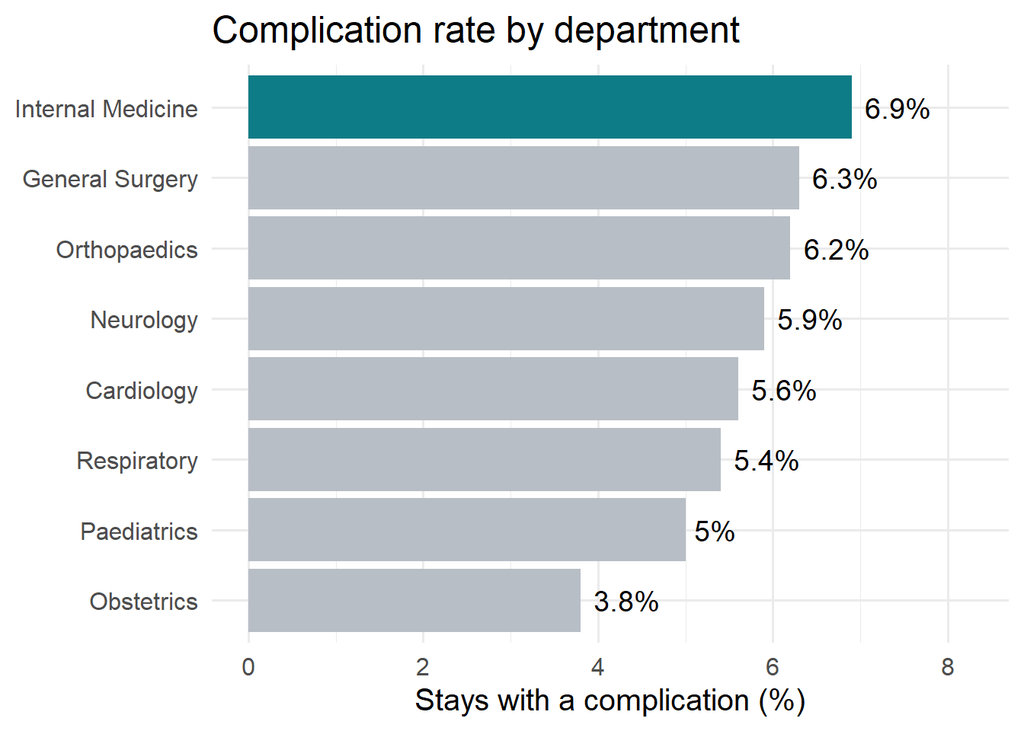

```r
# Bar chart of the complication rate, highlighting the highest department
g1 <- ggplot(q1, aes(x = reorder(department, complication_rate), y = complication_rate,
                     fill = department == q1$department[1])) +
  geom_col() +
  geom_text(aes(label = paste0(complication_rate, "%")), hjust = -0.2, size = 5) +
  coord_flip() +
  scale_fill_manual(values = c(col_grey, col_main), guide = "none") +
  scale_y_continuous(limits = c(0, max(q1$complication_rate) * 1.2)) +
  labs(title = "Complication rate by department",
       x = NULL, y = "Stays with a complication (%)") +
  theme_minimal(base_size = 15)
g1
```

```r
ggsave("charts/q1_complications.png", g1, width = 10, height = 5.6, dpi = 200, bg = "white")
```

**Answer:** Internal Medicine has the most complications: the highest rate (6.9%) and also the largest number (47 of its 683 stays), because it is also the biggest department. The rates are quite close, from 3.8% in Obstetrics to 6.9%, so no department stands out by a large margin.

## Question 2 – Mortality by admission type and severity

*Compute the mortality rate for every combination of admission_type and severity_level. Which combination is the most dangerous?*

```r
# Mortality rate (%) of every combination of admission type and severity
q2 <- data_clean %>%
  group_by(admission_type, severity_level) %>%
  summarise(admissions = n(),
            deaths = sum(discharge_destination == "Deceased"),
            mortality_rate = round(mean(discharge_destination == "Deceased") * 100, 1),
            .groups = "drop") %>%
  arrange(desc(mortality_rate))
q2
```

```
## # A tibble: 12 × 5
##    admission_type severity_level admissions deaths mortality_rate
##    <chr>                   <int>      <int>  <int>          <dbl>
##  1 Transfer in                 4          3      1           33.3
##  2 Emergency                   4         53     15           28.3
##  3 Transfer in                 3          8      1           12.5
##  4 Transfer in                 2         19      2           10.5
##  5 Emergency                   3        307     31           10.1
##  6 Emergency                   2        817     49            6
##  7 Elective                    2        151      2            1.3
##  8 Emergency                   1       1051     11            1
##  9 Elective                    1        246      1            0.4
## 10 Elective                    3         29      0            0
## 11 Elective                    4          2      0            0
## 12 Transfer in                 1         41      0            0
```

```r
# Most dangerous combination with at least 20 stays (enough cases to be reliable)
q2_reliable <- q2 %>% filter(admissions >= 20)
q2_reliable[1, ]
```

```
## # A tibble: 1 × 5
##   admission_type severity_level admissions deaths mortality_rate
##   <chr>                   <int>      <int>  <int>          <dbl>
## 1 Emergency                   4         53     15           28.3
```

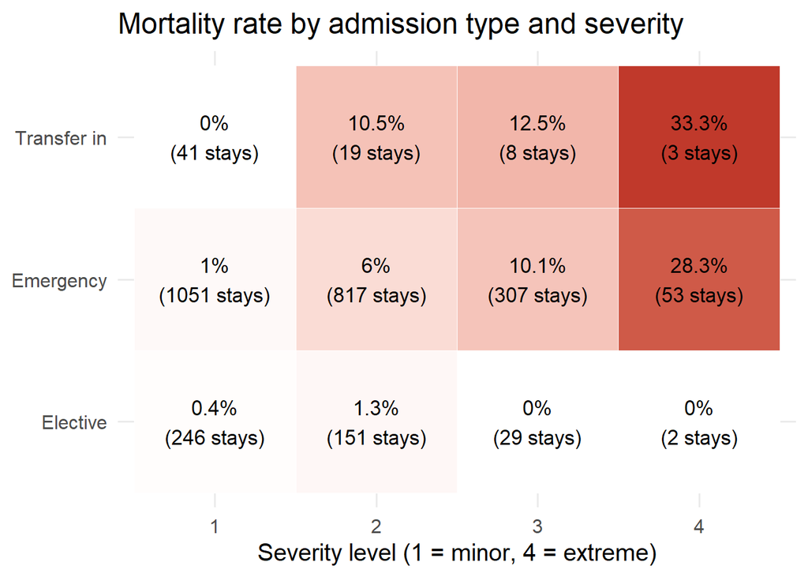

```r
# Heat map: one tile per combination with its mortality rate and number of stays
g2 <- ggplot(q2, aes(x = factor(severity_level), y = admission_type, fill = mortality_rate)) +
  geom_tile(colour = "white") +
  geom_text(aes(label = paste0(mortality_rate, "%\n(", admissions, " stays)")), size = 4.5) +
  scale_fill_gradient(low = "white", high = col_loss, guide = "none") +
  labs(title = "Mortality rate by admission type and severity",
       x = "Severity level (1 = minor, 4 = extreme)", y = NULL) +
  theme_minimal(base_size = 15)
g2
```

```r
ggsave("charts/q2_mortality.png", g2, width = 10, height = 5.6, dpi = 200, bg = "white")
```

**Answer:** The most dangerous combination is Emergency admissions with severity level 4: 28.3% of these patients died (15 of 53). Transfers with severity 4 show 33.3%, but they are only 3 stays, too few to draw conclusions. Mortality grows with severity, and planned (elective) stays almost never end in death.

## Question 3 – Admissions by day of the week

*Count the admissions on each day of the week of admission_datetime and plot them. Which days are the busiest and what happens at weekends?*

```r
# Day of the week as a number (1 = Monday ... 7 = Sunday), then as a label
day_names <- c("Mon", "Tue", "Wed", "Thu", "Fri", "Sat", "Sun")
q3 <- data_clean %>%
  mutate(weekday = factor(day_names[wday(admission_datetime, week_start = 1)],
                          levels = day_names)) %>%
  count(weekday, name = "admissions")
q3
```

```
##   weekday admissions
## 1     Mon        435
## 2     Tue        425
## 3     Wed        416
## 4     Thu        399
## 5     Fri        385
## 6     Sat        325
## 7     Sun        342
```

```r
# Average admissions per weekday and per weekend day
avg_weekday <- mean(q3$admissions[1:5])
avg_weekend <- mean(q3$admissions[6:7])
weekend_drop <- round((1 - avg_weekend / avg_weekday) * 100, 1)
weekend_drop
```

```
## [1] 19.1
```

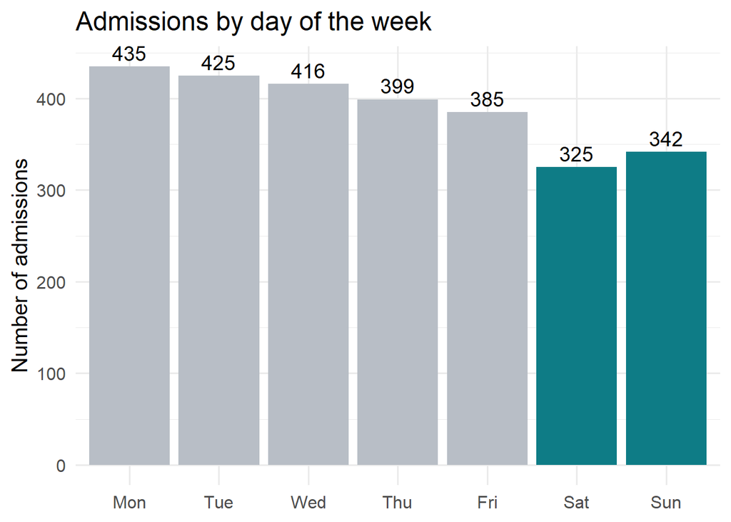

```r
# Bar chart in calendar order, highlighting the weekend
g3 <- ggplot(q3, aes(x = weekday, y = admissions, fill = weekday %in% c("Sat", "Sun"))) +
  geom_col() +
  geom_text(aes(label = admissions), vjust = -0.4, size = 5) +
  scale_fill_manual(values = c(col_grey, col_main), guide = "none") +
  labs(title = "Admissions by day of the week",
       x = NULL, y = "Number of admissions") +
  theme_minimal(base_size = 15)
g3
```

```r
ggsave("charts/q3_weekday.png", g3, width = 10, height = 5.6, dpi = 200, bg = "white")
```

**Answer:** The busiest day is Monday (435 admissions) and admissions fall a little every day until Friday (385). At weekends they drop: 334 admissions per weekend day against 412 per weekday, 19.1% fewer, because almost no planned operations are scheduled on Saturday or Sunday.

## Question 4 – Length of stay by age band

*Group age into bands (0–17, 18–44, 45–64, 65–74, 75–84, 85 or more) using conditionals. Compute the average length of stay of each band and plot it. From which age does the length of stay rise sharply?*

```r
# Age bands with conditionals, then average length of stay of each band
band_order <- c("0-17", "18-44", "45-64", "65-74", "75-84", "85 or more")
q4 <- data_clean %>%
  filter(!is.na(age)) %>%
  mutate(age_band = case_when(
    age <= 17 ~ "0-17",
    age <= 44 ~ "18-44",
    age <= 64 ~ "45-64",
    age <= 74 ~ "65-74",
    age <= 84 ~ "75-84",
    TRUE ~ "85 or more"
  )) %>%
  mutate(age_band = factor(age_band, levels = band_order)) %>%
  group_by(age_band) %>%
  summarise(admissions = n(),
            avg_los = round(mean(length_of_stay_days), 1)) %>%
  mutate(increase_vs_previous = avg_los - lag(avg_los))
q4
```

```
## # A tibble: 6 × 4
##   age_band   admissions avg_los increase_vs_previous
##   <fct>           <int>   <dbl>                <dbl>
## 1 0-17              202     2.5               NA
## 2 18-44             461     2.7                0.200
## 3 45-64             578     5.1                2.4
## 4 65-74             573     7.1                2
## 5 75-84             567    10.1                3
## 6 85 or more        345    12                  1.9
```

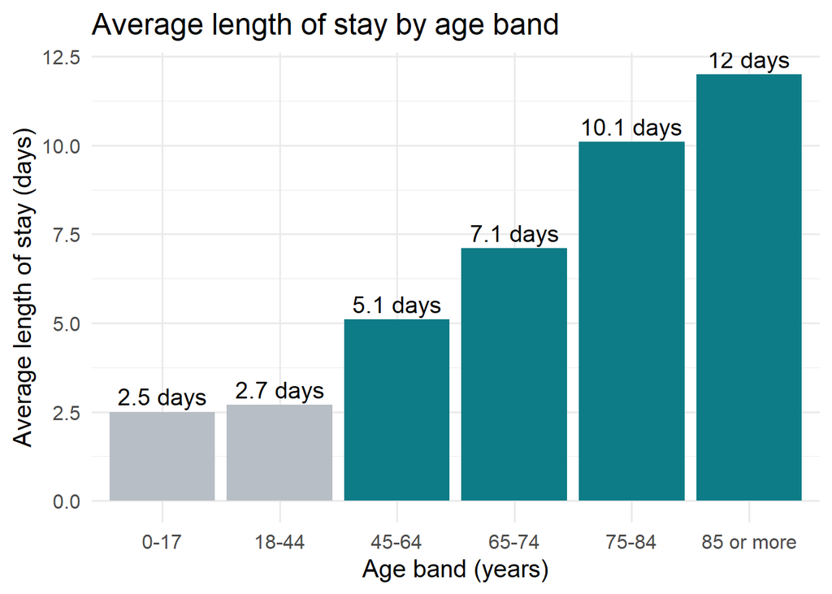

```r
# Bar chart in age order, highlighting the bands from 45 years
g4 <- ggplot(q4, aes(x = age_band, y = avg_los, fill = age_band %in% band_order[3:6])) +
  geom_col() +
  geom_text(aes(label = paste(avg_los, "days")), vjust = -0.4, size = 5) +
  scale_fill_manual(values = c(col_grey, col_main), guide = "none") +
  labs(title = "Average length of stay by age band",
       x = "Age band (years)", y = "Average length of stay (days)") +
  theme_minimal(base_size = 15)
g4
```

```r
ggsave("charts/q4_age.png", g4, width = 10, height = 5.6, dpi = 200, bg = "white")
```

**Answer:** The length of stay rises sharply from 45 years: it almost doubles from 2.7 days (18-44) to 5.1 days (45-64) and keeps growing in every band. The biggest jump is at 75-84 (+3 days), and patients aged 85 or more stay 12 days, almost five times longer than children (2.5 days).

## Question 5 – Weekend admissions and length of stay

*Patients admitted on a Friday or a Saturday stay longer than patients admitted from Tuesday to Thursday. Compute the average length of stay of both groups for all admissions, and then within each admission_type. Does the difference remain, shrink or reverse? Explain why.*

```r
# Label the two groups of days (Monday and Sunday are left out of the comparison)
data_q5 <- data_clean %>%
  mutate(day_number = wday(admission_datetime, week_start = 1),
         day_group = case_when(
           day_number %in% c(5, 6) ~ "Fri-Sat",
           day_number %in% c(2, 3, 4) ~ "Tue-Thu"
         )) %>%
  filter(!is.na(day_group))

# All admissions: average stay and share of planned (elective) stays in each group
q5_all <- data_q5 %>%
  group_by(day_group) %>%
  summarise(admissions = n(),
            avg_los = round(mean(length_of_stay_days), 2),
            elective_share = round(mean(admission_type == "Elective") * 100, 1))
q5_all
```

```
## # A tibble: 2 × 4
##   day_group admissions avg_los elective_share
##   <chr>          <int>   <dbl>          <dbl>
## 1 Fri-Sat          710    7.15            5.2
## 2 Tue-Thu         1240    6.54           22.2
```

```r
# Within each admission type
q5_type <- data_q5 %>%
  group_by(admission_type, day_group) %>%
  summarise(admissions = n(),
            avg_los = round(mean(length_of_stay_days), 2), .groups = "drop")
q5_type
```

```
## # A tibble: 6 × 4
##   admission_type day_group admissions avg_los
##   <chr>          <chr>          <int>   <dbl>
## 1 Elective       Fri-Sat           37    5.5
## 2 Elective       Tue-Thu          275    4.37
## 3 Emergency      Fri-Sat          653    7.28
## 4 Emergency      Tue-Thu          936    7.11
## 5 Transfer in    Fri-Sat           20    6.1
## 6 Transfer in    Tue-Thu           29    8.5
```

```r
# Difference in days (Fri-Sat minus Tue-Thu) for each admission type
q5_diff <- q5_type %>%
  select(admission_type, day_group, avg_los) %>%
  pivot_wider(names_from = day_group, values_from = avg_los) %>%
  mutate(difference = round(`Fri-Sat` - `Tue-Thu`, 2))
q5_diff
```

```
## # A tibble: 3 × 4
##   admission_type `Fri-Sat` `Tue-Thu` difference
##   <chr>              <dbl>     <dbl>      <dbl>
## 1 Elective            5.5       4.37       1.13
## 2 Emergency           7.28      7.11       0.17
## 3 Transfer in         6.1       8.5       -2.4
```

```r
diff_all <- round(q5_all$avg_los[1] - q5_all$avg_los[2], 2)
```

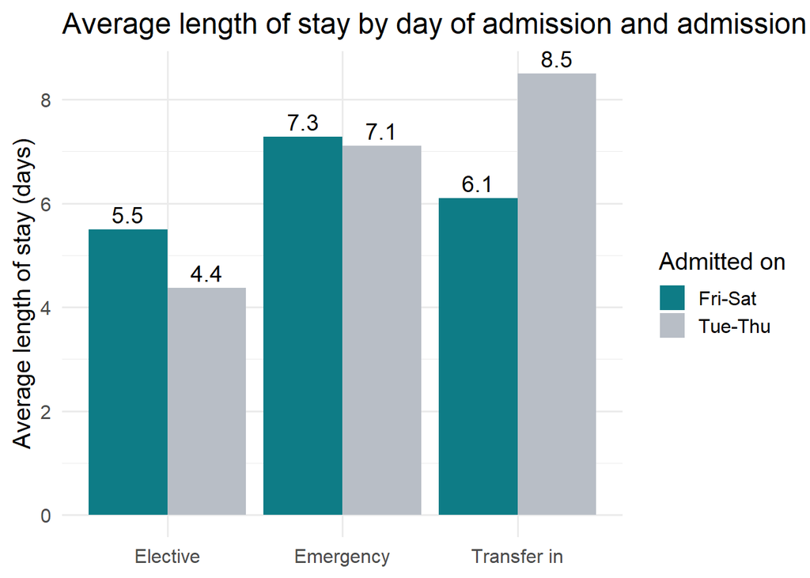

```r
# Grouped bars: both groups of days inside each admission type
g5 <- ggplot(q5_type, aes(x = admission_type, y = avg_los, fill = day_group)) +
  geom_col(position = "dodge") +
  geom_text(aes(label = round(avg_los, 1)), position = position_dodge(width = 0.9),
            vjust = -0.4, size = 5) +
  scale_fill_manual(values = c("Fri-Sat" = col_main, "Tue-Thu" = col_grey)) +
  labs(title = "Average length of stay by day of admission and admission type",
       x = NULL, y = "Average length of stay (days)", fill = "Admitted on") +
  theme_minimal(base_size = 15)
g5
```

```r
ggsave("charts/q5_weekend.png", g5, width = 10, height = 5.6, dpi = 200, bg = "white")
```

**Answer:** Overall, patients admitted on Friday or Saturday stay 7.15 days against 6.54 (+0.61 days). Within emergencies, which are most of the stays, the difference shrinks to 0.17 days, and for transfers it reverses (-2.4 days), although transfers are few. The overall gap comes mostly from the mix of patients: 22.2% of Tuesday-Thursday admissions are short planned stays against only 5.2% on Friday-Saturday, so the weekend groups are mainly longer emergency stays. Planned stays starting on Friday-Saturday are longer (+1.13 days), but they are only 37 cases.

## Question 6 – Concentration of cost

*Sort the admissions by cost_eur from highest to lowest. What share of the total cost comes from the top 5% and from the top 10% of admissions? What share of the top 5% spent time in intensive care (icu_days above 0), compared with all admissions?*

```r
# Sort from the most to the least expensive stay
sorted_cost <- data_clean %>% arrange(desc(cost_eur))
head(sorted_cost %>% select(admission_id, diagnosis_group, length_of_stay_days, icu_days, cost_eur))
```

```
##   admission_id diagnosis_group length_of_stay_days icu_days cost_eur
## 1      A700422       Pneumonia               50.69        6 59869.66
## 2      A700917    Hip fracture               52.70        0 53011.73
## 3      A702463 Elderly frailty               42.81        4 52206.63
## 4      A702157 Elderly frailty               45.49        0 44626.60
## 5      A700592    Hip fracture               43.15        0 44483.38
## 6      A701702    Hip fracture               37.41        0 43085.79
```

```r
# Number of stays in the top 5% and top 10%
n_stays <- nrow(sorted_cost)
n_top5  <- ceiling(n_stays * 0.05)
n_top10 <- ceiling(n_stays * 0.10)
total_cost <- sum(sorted_cost$cost_eur)

# Share of the total cost of each group (%)
share_top5  <- round(sum(sorted_cost$cost_eur[1:n_top5]) / total_cost * 100, 1)
share_top10 <- round(sum(sorted_cost$cost_eur[1:n_top10]) / total_cost * 100, 1)

# Share of stays with intensive care (%)
icu_top5 <- round(mean(sorted_cost$icu_days[1:n_top5] > 0) * 100, 1)
icu_all  <- round(mean(sorted_cost$icu_days > 0) * 100, 1)

q6 <- data.frame(group = c("Top 5% of stays", "Top 10% of stays", "All stays"),
                 stays = c(n_top5, n_top10, n_stays),
                 share_of_total_cost = c(share_top5, share_top10, 100),
                 icu_share = c(icu_top5, NA, icu_all))
q6
```

```
##              group stays share_of_total_cost icu_share
## 1  Top 5% of stays   137                17.6      35.8
## 2 Top 10% of stays   273                28.9        NA
## 3        All stays  2727               100.0       6.2
```

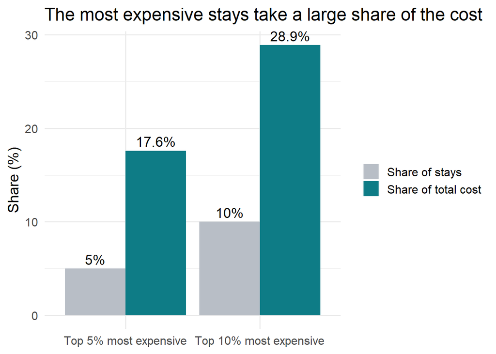

```r
# Share of the stays versus share of the cost for the most expensive stays
q6_chart <- data.frame(
  group = rep(c("Top 5% most expensive", "Top 10% most expensive"), times = 2),
  measure = rep(c("Share of stays", "Share of total cost"), each = 2),
  value = c(5, 10, share_top5, share_top10)
)
# Keep the top 5% first in the chart
q6_chart$group <- factor(q6_chart$group, levels = c("Top 5% most expensive", "Top 10% most expensive"))
g6 <- ggplot(q6_chart, aes(x = group, y = value, fill = measure)) +
  geom_col(position = "dodge") +
  geom_text(aes(label = paste0(value, "%")), position = position_dodge(width = 0.9),
            vjust = -0.4, size = 5) +
  scale_fill_manual(values = c("Share of stays" = col_grey, "Share of total cost" = col_main)) +
  labs(title = "The most expensive stays take a large share of the cost",
       x = NULL, y = "Share (%)", fill = NULL) +
  theme_minimal(base_size = 15)
g6
```

```r
ggsave("charts/q6_cost.png", g6, width = 10, height = 5.6, dpi = 200, bg = "white")
```

**Answer:** The 137 most expensive stays (top 5%) account for 17.6% of the total cost, and the top 10% for 28.9%. Intensive care explains a large part: 35.8% of the top 5% spent time in intensive care, against 6.2% of all stays, almost 6 times more.

## Question 7 – Margin by payer

*Compute the margin of every admission. Add it up by payer. Which payers lose money for the hospital, and what share of all admissions lose money?*

```r
# Margin of every stay: amount paid minus cost
data_clean <- data_clean %>% mutate(margin = reimbursement_eur - cost_eur)

# Total and average margin by payer, and share of stays that lose money
q7 <- data_clean %>%
  group_by(payer) %>%
  summarise(admissions = n(),
            total_margin = round(sum(margin)),
            avg_margin = round(mean(margin)),
            loss_share = round(mean(margin < 0) * 100, 1)) %>%
  arrange(total_margin)
q7
```

```
## # A tibble: 4 × 5
##   payer                 admissions total_margin avg_margin loss_share
##   <chr>                      <int>        <dbl>      <dbl>      <dbl>
## 1 Public agreement            1736      -622966       -359       44
## 2 Civil servants mutual        274        39149        143       33.9
## 3 Self-pay                      66        43255        655       27.3
## 4 Private insurer              651       512919        788        6.1
```

```r
# Share of all stays that lose money and total margin of the hospital
loss_share_all <- round(mean(data_clean$margin < 0) * 100, 1)
total_margin_all <- sum(data_clean$margin)
loss_share_all
```

```
## [1] 33.6
```

```r
total_margin_all
```

```
## [1] -27643.92
```

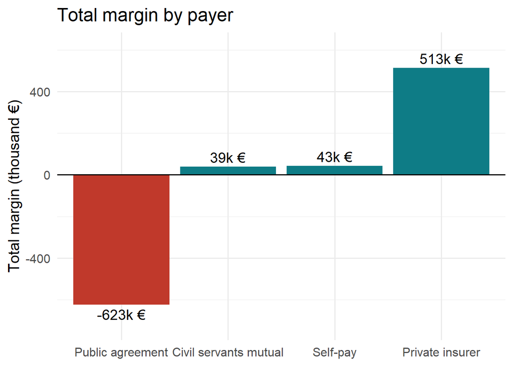

```r
# Total margin by payer in thousands of euros: red for losses
g7 <- ggplot(q7, aes(x = reorder(payer, total_margin), y = total_margin / 1000,
                     fill = total_margin < 0)) +
  geom_col() +
  geom_text(aes(label = paste0(round(total_margin / 1000), "k €"),
                vjust = ifelse(total_margin < 0, 1.4, -0.4)), size = 5) +
  geom_hline(yintercept = 0) +
  scale_fill_manual(values = c(col_main, col_loss), guide = "none") +
  scale_y_continuous(expand = expansion(mult = 0.15)) +
  labs(title = "Total margin by payer",
       x = NULL, y = "Total margin (thousand €)") +
  theme_minimal(base_size = 15)
g7
```

```r
ggsave("charts/q7_margin.png", g7, width = 10, height = 5.6, dpi = 200, bg = "white")
```

**Answer:** Only Public agreement loses money: -€622,966 in total (-€359 per stay), and 44% of its 1736 stays lose money. The other payers are profitable, especially Private insurer (€512,919). Overall, 33.6% of all stays lose money and the hospital as a whole has a margin of -€27,644, because the public agreement pays most of the stays.

## Question 8 – Labelling the stays

*Write a function that labels a stay “Very long” if length_of_stay_days is more than 14 or icu_days is 3 or more, “Long” if length_of_stay_days is more than 7, “Short” if it is less than 2, and “Normal” otherwise (check the rules in the order given). Apply it to every admission with a loop. Count the labels by department and compare the average cost_eur of the four labels.*

```r
# Function: checks the rules in the order given and returns the label
label_stay <- function(los, icu) {
  if (los > 14 | icu >= 3) {
    return("Very long")
  } else if (los > 7) {
    return("Long")
  } else if (los < 2) {
    return("Short")
  } else {
    return("Normal")
  }
}

# Loop: apply the function to every admission
stay_label <- character(nrow(data_clean))
for (i in 1:nrow(data_clean)) {
  stay_label[i] <- label_stay(data_clean$length_of_stay_days[i], data_clean$icu_days[i])
}
data_clean$stay_label <- factor(stay_label, levels = c("Short", "Normal", "Long", "Very long"))

# Number of stays of each label by department
q8_dept <- data_clean %>%
  count(department, stay_label) %>%
  pivot_wider(names_from = stay_label, values_from = n, values_fill = 0)
q8_dept
```

```
## # A tibble: 8 × 5
##   department        Short Normal  Long `Very long`
##   <chr>             <int>  <int> <int>       <int>
## 1 Cardiology           48    193    72          41
## 2 General Surgery     122    121    22           4
## 3 Internal Medicine     3    267   277         136
## 4 Neurology            22     87    58          35
## 5 Obstetrics          144    143     2           2
## 6 Orthopaedics          4    203    88          60
## 7 Paediatrics          95    103     1           1
## 8 Respiratory           0    187   149          37
```

```r
# Number of stays and average cost of each label
q8_cost <- data_clean %>%
  group_by(stay_label) %>%
  summarise(stays = n(),
            avg_cost = round(mean(cost_eur)))
q8_cost
```

```
## # A tibble: 4 × 3
##   stay_label stays avg_cost
##   <fct>      <int>    <dbl>
## 1 Short        438     2010
## 2 Normal      1304     5152
## 3 Long         669     9390
## 4 Very long    316    19414
```

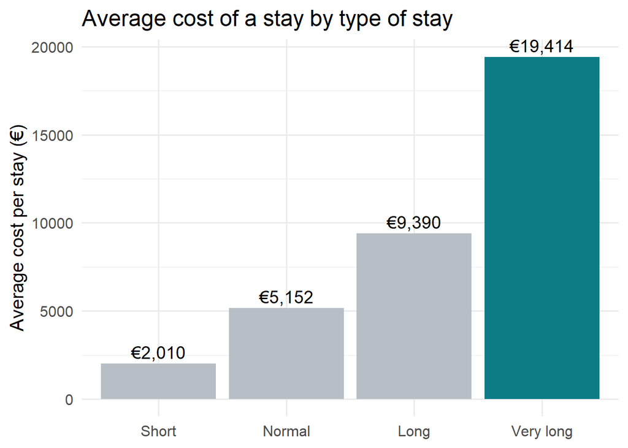

```r
# Average cost of each label, from the shortest to the longest stays
g8 <- ggplot(q8_cost, aes(x = stay_label, y = avg_cost, fill = stay_label == "Very long")) +
  geom_col() +
  geom_text(aes(label = eur(avg_cost)), vjust = -0.4, size = 5) +
  scale_fill_manual(values = c(col_grey, col_main), guide = "none") +
  labs(title = "Average cost of a stay by type of stay",
       x = NULL, y = "Average cost per stay (€)") +
  theme_minimal(base_size = 15)
g8
```

```r
ggsave("charts/q8_labels.png", g8, width = 10, height = 5.6, dpi = 200, bg = "white")
```

**Answer:** A “Very long” stay costs on average €19,414, about 3.8 times a “Normal” stay (€5,152) and 10 times a “Short” one (€2,010). There are 316 very long stays (11.6% of all). By department, Internal Medicine has the most very long stays (136), and it has more “Long” than “Normal” stays. General Surgery, Obstetrics and Paediatrics have almost only short and normal stays.

## Question 9 – Patient satisfaction

*How satisfied are patients with their stay in each department (if available)?*

```r
# Look for any column about satisfaction in the data
names(data_clean)
```

```
##  [1] "admission_id"           "patient_id"             "admission_datetime"
##  [4] "discharge_datetime"     "length_of_stay_days"    "admission_type"
##  [7] "department"             "diagnosis_group"        "age"
## [10] "payer"                  "comorbidity_index"      "severity_level"
## [13] "surgery_flag"           "icu_days"               "complications_flag"
## [16] "consultant_id"          "waiting_list_days"      "ed_boarding_hours"
## [19] "hospital_occupancy_pct" "discharge_destination"  "cost_eur"
## [22] "reimbursement_eur"      "margin"                 "stay_label"
```

```r
any(grepl("satisf", names(data_clean), ignore.case = TRUE))
```

```
## [1] FALSE
```

**Answer:** This question cannot be answered: the data has no column about patient satisfaction (no survey score, complaint or rating), as the check above shows. To answer it the hospital would need a satisfaction survey for each stay (for example a score from 0 to 10 collected at discharge) linked to the `admission_id`, so it could be averaged by department.

## Question 10 – One day less for knee and hip replacements

*Suppose the hospital shortens by one day the stay of every knee and hip replacement. How many bed-days and how much cost would it save (use the cost per bed-day), and how many more operations of this type could be done in the freed beds (divide the freed bed-days by the new, shorter stay)?*

```r
# Cost per bed-day of the whole hospital
cost_per_bedday <- sum(data_clean$cost_eur) / sum(data_clean$length_of_stay_days)
round(cost_per_bedday, 2)
```

```
## [1] 1076.2
```

```r
# Knee and hip replacements
joints <- data_clean %>%
  filter(diagnosis_group %in% c("Knee replacement", "Hip replacement"))
n_joints <- nrow(joints)

# One day less for each of them
beddays_saved <- n_joints * 1
cost_saved <- beddays_saved * cost_per_bedday

# Current and new (one day shorter) average stay of these operations
current_los <- mean(joints$length_of_stay_days)
new_los <- current_los - 1

# Extra operations that fit in the freed bed-days (whole operations only)
extra_operations <- floor(beddays_saved / new_los)

q10 <- data.frame(measure = c("Knee and hip replacements", "Bed-days saved",
                              "Cost per bed-day (€)", "Cost saved (€)",
                              "Current average stay (days)", "New average stay (days)",
                              "Extra operations possible"),
                  value = c(n_joints, beddays_saved, round(cost_per_bedday),
                            round(cost_saved), round(current_los, 2), round(new_los, 2),
                            extra_operations))
q10
```

```
##                       measure     value
## 1   Knee and hip replacements    177.00
## 2              Bed-days saved    177.00
## 3        Cost per bed-day (€)   1076.00
## 4              Cost saved (€) 190488.00
## 5 Current average stay (days)      5.16
## 6     New average stay (days)      4.16
## 7   Extra operations possible     42.00
```

**Answer:** There are 177 knee and hip replacements, so one day less each frees 177 bed-days. At €1,076 per bed-day, this saves about €190,488. With the shorter stay (from 5.2 to 4.2 days), the freed beds would allow 42 more operations of this type per year.

# 5. Conclusions

- **The public agreement loses money:** it pays 1736 of the 2727 stays and generates a loss of -€622,966; 33.6% of all stays lose money. **Recommendation:** review the tariffs and the costs of the diagnoses with the largest losses with the regional health service.
- **Few stays drive the cost:** the top 5% most expensive stays make up 17.6% of the cost and 35.8% of them used intensive care (vs 6.2%); a “Very long” stay costs €19,414 on average. **Recommendation:** follow up long and intensive-care stays from the first days to plan the discharge.
- **Older patients stay much longer:** from 45 years the stay grows in every band, up to 12 days for patients aged 85 or more. **Recommendation:** plan geriatric and social-care support (nursing homes, home care) before discharge, especially in winter.
- **Shorter joint replacements free beds:** one day less in knee and hip replacements saves 177 bed-days (€190,488) or allows 42 more operations. **Recommendation:** apply a fast-recovery protocol to these operations.
- **Weekends:** admissions drop 19.1% at weekends; the longer stays of Friday-Saturday admissions are mainly due to the type of patient, not the day.